# Bartik, Shift Share, and Formula Instruments

Joel Ferguson

## Basics

$Z_{i,t} = \sum\limits_{k\in\mathcal{K}}w^k_{i}g^k_{t}$

- $w^k_{i}$: Shares, e.g. share of employment in industry $k$
- $g^k_{t}$: Shifts, e.g. growth rate of industry $k$

## Three Paths to Identification

- Shares are Exogenous: Goldsmith-Pinkham, Sorkin, and Swift (2020) AER
- Shifts are Exogenous: Borusyak, Hull, and Jaravel (2022) REStud
- Special Case of Non-Random Exposure to Exogenous Shocks: Borusyak and Hull (forthcoming) Ecma

Differ in what variation drives causal identification and how to do statistical inference

## Shares are Exogenous

SSIV is **numerically equivalent** to GMM with shares as instruments

- Weighting matrix: Outer product of the shifts

In this case, identifying assumption is that shares are uncorrelated with unobserved determinants of outcome, conditional on controls

- Much more palatable if outcomes is in **changes** and shares are held constant at baseline values

## Shares are Exogenous: Math

$Y_{i,t} = \alpha + \beta D_{i,t} + X_{i,t} \Gamma+ \varepsilon_{i,t}$

**Assumption**: $\mathbb{E}[\varepsilon_{i,t}w^k_{i}|X_{i,t}]=0$

**Instrument**: $Z_{i,t} = \sum\limits_{k\in\mathcal{K}}w^k_{i}g^k_{t}$

Equivalent to GMM with $W$ as instruments $G_tG_t'$ as weighting matrix

$\frac{X^{\perp'}W(GG')W'Y^{\perp}}{X^{\perp'}W(GG')W'X^{\perp}}\rightarrow\beta$

## Shares are Exogenous: Code

```r
set.seed(1115)
N = 3000 # Number of units
K = 10 # Number of industries

w = matrix(runif(N*K),
           nrow=N,
           ncol=K) # Shares are an NxK matrix
# Normalize shares to sum to 1
w = w/as.vector((w%*%matrix(1,nrow=K,ncol=1)))

g = matrix(runif(K,-1,1),
           nrow=K,
           ncol=1) # Shifts are Kx1 vector

Z = w%*%g # Shift share

X = runif(N,-1,1) # Control
e = rnorm(N,0,0.1)  # Errors
D = as.vector(Z) + e # Treatment correlated with error

Y = D + X + e # True effect of treatment is 1

# Put stuff in matrices
Y = matrix(Y,nrow=N,ncol=1)

rhs = cbind(
  matrix(1,nrow=N,ncol=1), # Constant
  matrix(X,nrow=N,ncol=1), # Control
  matrix(D,nrow=N,ncol=1)  # Treatment
)

rhs_short = cbind(
  matrix(1,nrow=N,ncol=1), # Constant
  matrix(X,nrow=N,ncol=1) # Control
)

# Annhilator matrix
annh = diag(N) -
  rhs_short%*%solve(t(rhs_short)%*%rhs_short)%*%t(rhs_short)


inst = cbind(
  matrix(1,nrow=N,ncol=1), # Constant
  matrix(X,nrow=N,ncol=1), # Control
  Z  # instrument
)

shift_share_iv_coef = solve(t(inst)%*%rhs) %*% (t(inst)%*%Y)
print(paste("Shift Share IV Coef:", shift_share_iv_coef[3,1]))
```

```
[1] "Shift Share IV Coef: 1.00437876156168"
```

## Shares are Exogenous: Code

```r
Y_fwl = annh%*%Y
D_fwl = annh%*%D

gmm_coef = (t(D_fwl)%*%w%*%(g%*%t(g))%*%t(w)%*%Y_fwl) /
  (t(D_fwl)%*%w%*%(g%*%t(g))%*%t(w)%*%D_fwl)
print(paste("Shift Share IV Coef:", shift_share_iv_coef[3,1]))
```

```
[1] "Shift Share IV Coef: 1.00437876156168"
```

```r
print(paste("GMM Coef:", gmm_coef))
```

```
[1] "GMM Coef: 1.00437876156166"
```

## Shares are Exogenous: Takeaways

- If shares are exogenous, SSIV is numerically equivalent to GMM with shares as instruments and shifts as weights
- Can be more palatable if outcome is specified in changes and shares are set at some baseline level
- Generally hard to think of a design that generates this assumption though

## Shifts are Exogenous

There is a numerical equivalence between SSIV and a shift-level IV where the shift is the instrument

- **Outcome:** share-weighted outcome
- **Treatment:** share-weighted treatment

Here, identification comes from shifts being uncorrelated with unobserved determinants, rather than shares

- Potentially lends itself more easily to design-based inference

## Shifts are Exogenous: Math

Standard IV orthogonality is equivalent to shock-level exogeneity

$\mathbb{E}[\sum\limits_{k\in\mathcal{K}} w^kg_t^k\bar{\varepsilon}_{k,t}]=0$

Where $\bar{\varepsilon}_{k,t}=\frac{\sum\limits_{i}w_{i}^k\varepsilon_{i,t}}{\sum\limits_{i}w_i^k}$

And SSIV estimator is equivalent to a share-weighted IV estimator using shocks $g_t^k$ as instruments

$\bar{Y}^{\perp}_{n,t}=\beta \bar{D}^{\perp}_{n,t}+\bar{\varepsilon}^{\perp}_{n,t}$

## Shifts are Exogenous: Code

```r
Y_bar = t(w)%*%Y_fwl # Weight FWL'd outcomes by shares
# Y_bar is KxN%*%Nx1 = Kx1
D_bar = t(w)%*%D_fwl # Same for treatment

shock_iv_coef = solve(t(g)%*%D_bar)%*%(t(g)%*%Y_bar) # IV
print(paste("Shift Share IV Coef:", shift_share_iv_coef[3,1]))
```

```
[1] "Shift Share IV Coef: 1.00437876156168"
```

```r
print(paste("Shock-level IV Coef:", shock_iv_coef))
```

```
[1] "Shock-level IV Coef: 1.00437876156166"
```

## Shifts are Exogenous: Takeaways

- SSIV is equivalent to shock-level IV with shock as instrument
- Shocks are level of treatment assignment, so need many shocks for good inference
- Easier to think of how a design assigns shocks than shares

## SSIV as a Special Case of Non-Random Exposure

$Z_{i,t} = \sum\limits_{k\in\mathcal{K}}w^k_{i}g^k_{t}$ is a special case of $Z_{i,t}=h(g_t;w_i)$

When shares are correlated with unobserved determinants of the outcome and shifts aren’t all mean zero, SSIV can be biased

- **Solution**: Re-center instrument around expectation $Z_{i,t}-\mathbb{E}[Z_{i,t}]$

## SSIV as a Special Case of Non-Random Exposure: Math

$\frac{1}{NT}\sum\limits_{i,t} \mathbb{E}[Z_{i,t}\varepsilon_{i,t}]=\frac{1}{NT}\sum\limits_{i,t} \mathbb{E}[\mathbb{E}[h(g_t;w_i)|w_i]\varepsilon_{i,t}]$

Not necessarily zero unless observation-level expected shocks are uncorrelated with unobservables

- Re-centering mechanically removes correlation

## SSIV as a Special Case of Non-Random Exposure: Code

```r
g_means = runif(K,0,5)

g = matrix(sapply(g_means,function(x) rnorm(1,x,1)),
              nrow=K,
              ncol=1) # Shifts are Kx1 vector

Z = w%*%g # Shift share
mu = w%*%g_means
Z_rc = Z-mu

# Errors correlated with expected instrument
e1 = sapply(as.vector(mu),
            function(x) rnorm(1,x,0.3))
e2 = sapply(e1,
            function(x) rnorm(1,x,0.1))

D = as.vector(Z) + e1 # Treatment correlated with error

Y = D + X + e2 # True effect of treatment is 1

# Put stuff in matrices
Y = matrix(Y,nrow=N,ncol=1)

rhs = cbind(
  matrix(1,nrow=N,ncol=1), # Constant
  matrix(X,nrow=N,ncol=1), # Control
  matrix(D,nrow=N,ncol=1)  # Treatment
)

rhs_short = cbind(
  matrix(1,nrow=N,ncol=1), # Constant
  matrix(X,nrow=N,ncol=1) # Control
)

# Annhilator matrix
annh = diag(N) -
  rhs_short%*%solve(t(rhs_short)%*%rhs_short)%*%t(rhs_short)


inst = cbind(
  matrix(1,nrow=N,ncol=1), # Constant
  matrix(X,nrow=N,ncol=1), # Control
  Z  # instrument
)

shift_share_iv_coef = solve(t(inst)%*%rhs) %*% (t(inst)%*%Y)
print(paste("Shift Share IV Coef:", shift_share_iv_coef[3,1]))
```

```
[1] "Shift Share IV Coef: 1.38369346953507"
```

## SSIV as a Special Case of Non-Random Exposure: Code

```r
recentered_iv_coef = solve(t(Z_rc)%*%D_fwl) %*% (t(Z_rc)%*%Y_fwl)
print(paste("Re-centered IV Coef:", recentered_iv_coef))
```

```
[1] "Re-centered IV Coef: 0.957521500615535"
```

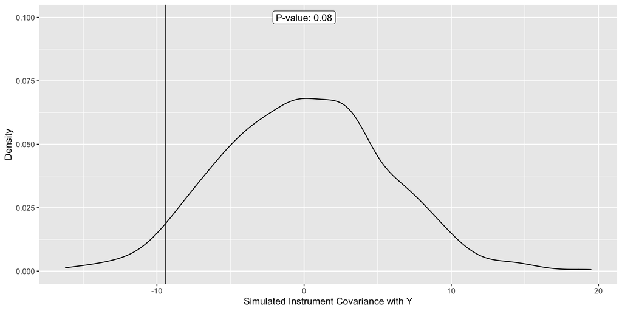

## SSIV as a Special Case of Non-Random Exposure: Takeaways

- Problems can arise in SSIV when expected exposure to shifts is correlated with unobservables
- Possible to do proper design-based inference even in these tricky cases
- Requires knowledge of shock distribution to perform re-centering and do finite-sample inference

## A Word on Inference

- With exogenous shares it isn’t immediately obvious how to do proper statistical inference
- With exogenous shifts heteroskedasticity robust SEs of shock-level regression are valid under large number of uncorrelated shocks assumption (similar conclusions from Adão et al. 2019)
- With non-random exposure, finite sample randomization inference is possible using correlation between (simulated) re-centered instrument and (FWL’d) outcome